## Exercise 6.9

**In this exercise, we will predict the number of applications received using the other variables in the College data set.**

1. **Split the data set into a training set and a test set.**

```r
require(ISLR)
require(caret)
require(tidyverse)
data('College')
set.seed(1)

inTrain <- createDataPartition(College$Apps, p = 0.75, list = FALSE)

training <- College[inTrain,]
testing <- College[-inTrain,]

preObj <- preProcess(training, method = c('center', 'scale'))

training <- predict(preObj, training)
testing <- predict(preObj, testing)

y_train <- training$Apps
y_test <- testing$Apps

one_hot_encoding <- dummyVars(Apps ~ ., data = training)
x_train <- predict(one_hot_encoding, training)
x_test <- predict(one_hot_encoding, testing)
```

2. **Fit a linear model using least squares on the training set, and report the test error obtained.**

```r
lin_model <- lm(Apps ~ ., data = training)

pred <- predict(lin_model, testing)

(lin_info <- postResample(pred, testing$Apps))
```

```
##      RMSE  Rsquared       MAE
## 0.2799768 0.9201765 0.1568743
```

3. **Fit a ridge regression model on the training set, with $\lambda$ chosen by cross-validation. Report the test error obtained.**

```r
ridge_fit <- train(x = x_train, y = y_train,
                   method = 'glmnet',
                   trControl = trainControl(method = 'cv', number = 10),
                   tuneGrid = expand.grid(alpha = 0,
                                          lambda = seq(0, 10e2, length.out = 20)))
(ridge_info <- postResample(predict(ridge_fit, x_test), y_test))
```

```
##      RMSE  Rsquared       MAE
## 0.2853247 0.9211286 0.1645806
```

```r
coef(ridge_fit$finalModel, ridge_fit$bestTune$lambda)
```

```
## 19 x 1 sparse Matrix of class "dgCMatrix"
##                       s1
## (Intercept)  0.034871314
## Private.No   0.075423210
## Private.Yes -0.076037580
## Accept       0.665628733
## Enroll       0.090243372
## Top10perc    0.107160248
## Top25perc    0.011628030
## F.Undergrad  0.063308801
## P.Undergrad  0.017427317
## Outstate    -0.028995432
## Room.Board   0.048720533
## Books        0.012799145
## Personal    -0.002894430
## PhD         -0.017989250
## Terminal    -0.010434665
## S.F.Ratio    0.006920126
## perc.alumni -0.031683867
## Expend       0.083525070
## Grad.Rate    0.058131023
```

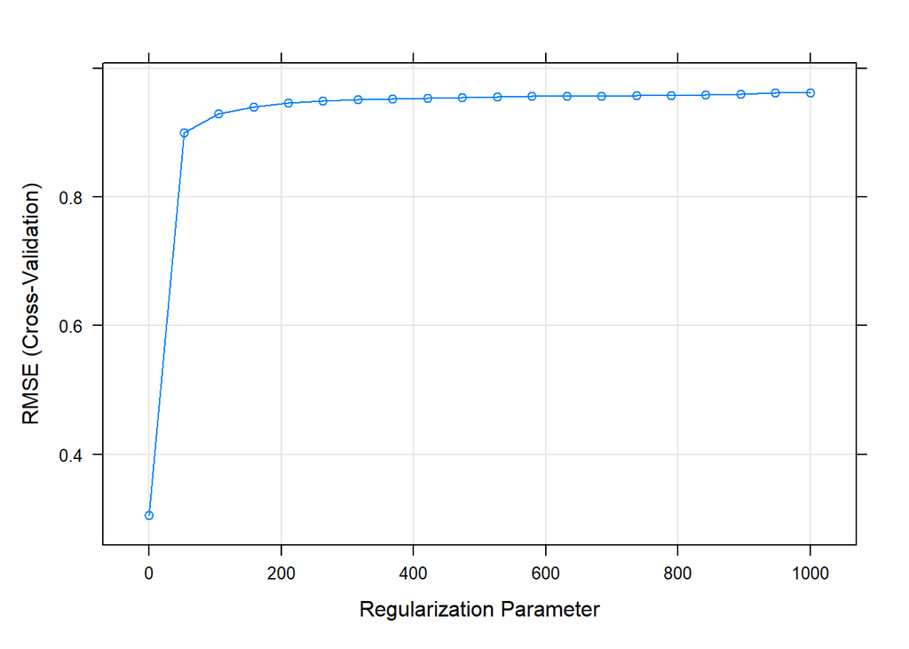

```r
plot(ridge_fit)
```

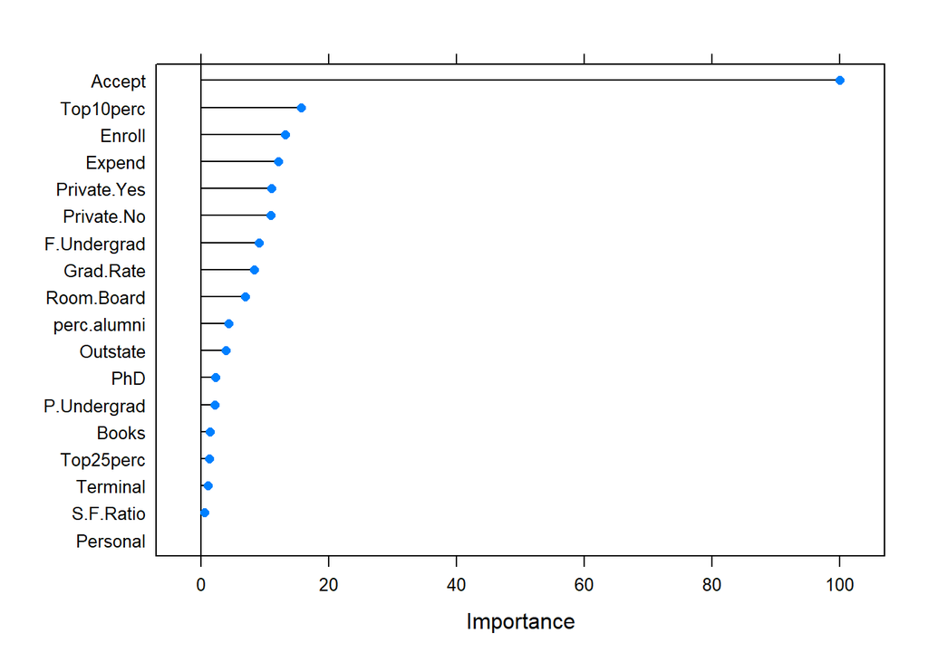

```r
plot(varImp(ridge_fit))
```

4. **Fit a lasso model on the training set, with $\lambda$ chosen by cross-validation. Report the test error obtained, along with the number of non-zero coefficient estimates.**

```r
lasso_fit <- train(x = x_train, y = y_train,
                   method = 'glmnet',
                   trControl = trainControl(method = 'cv', number = 10),
                   tuneGrid = expand.grid(alpha = 1,
                                          lambda = seq(0.0001, 1, length.out = 50)))
(lasso_info <- postResample(predict(lasso_fit, x_test), y_test))
```

```
##      RMSE  Rsquared       MAE
## 0.2914812 0.9141364 0.1511801
```

```r
coef(lasso_fit$finalModel, lasso_fit$bestTune$lambda)
```

```
## 19 x 1 sparse Matrix of class "dgCMatrix"
##                        s1
## (Intercept) -1.470609e-02
## Private.No   5.410732e-02
## Private.Yes  .
## Accept       8.883839e-01
## Enroll       .
## Top10perc    1.092201e-01
## Top25perc    .
## F.Undergrad  .
## P.Undergrad  .
## Outstate     .
## Room.Board   1.483337e-04
## Books        .
## Personal     .
## PhD          .
## Terminal     .
## S.F.Ratio    .
## perc.alumni  .
## Expend       4.067011e-02
## Grad.Rate    4.062721e-06
```

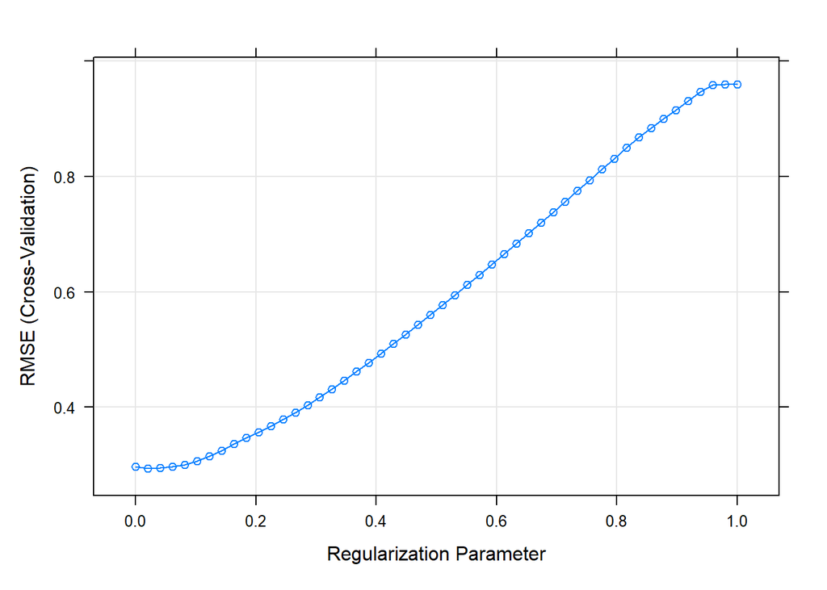

```r
plot(lasso_fit)
```

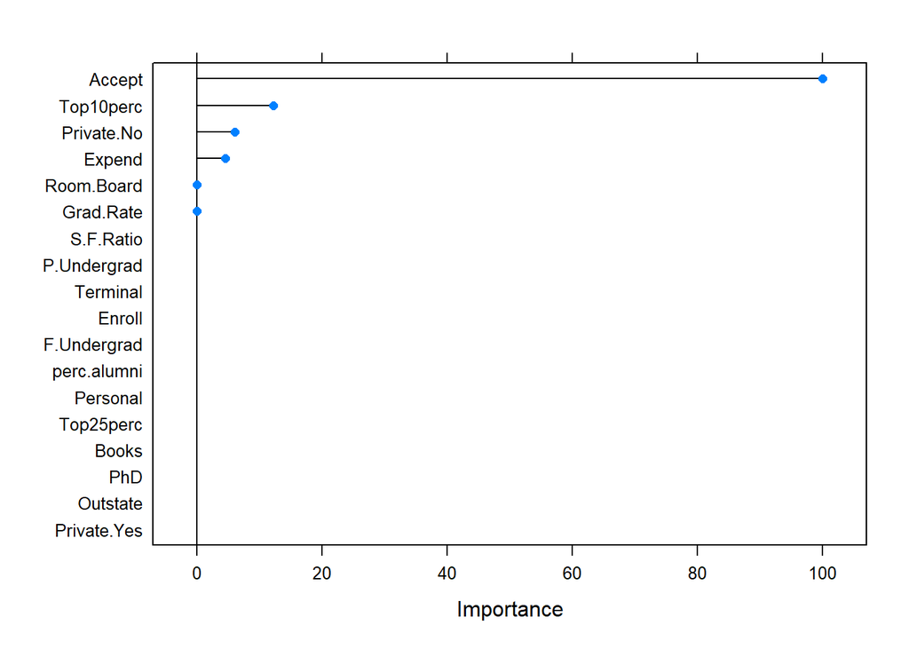

```r
plot(varImp(lasso_fit))
```

5. **Fit a PCR model on the training set, with M chosen by cross validation. Report the test error obtained, along with the value of M selected by cross-validation.**

```r
pcr_model <- train(x = x_train, y = y_train,
                   method = 'pcr',
                   trControl = trainControl(method = 'cv', number = 10),
                   tuneGrid = expand.grid(ncomp = 1:10))
(pcr_info <- postResample(predict(pcr_model, x_test), y_test))
```

```
##      RMSE  Rsquared       MAE
## 0.3231292 0.8916531 0.1986075
```

```r
coef(pcr_model$finalModel)
```

```
## , , 10 comps
##
##                 .outcome
## Private.No   0.031985972
## Private.Yes -0.031985972
## Accept       0.343576750
## Enroll       0.305359773
## Top10perc    0.042630417
## Top25perc    0.027790893
## F.Undergrad  0.273818439
## P.Undergrad -0.049487667
## Outstate     0.038573119
## Room.Board   0.070607615
## Books        0.016433593
## Personal    -0.023529455
## PhD         -0.023992433
## Terminal    -0.024182230
## S.F.Ratio    0.003741623
## perc.alumni -0.070567887
## Expend       0.090126298
## Grad.Rate    0.071302714
```

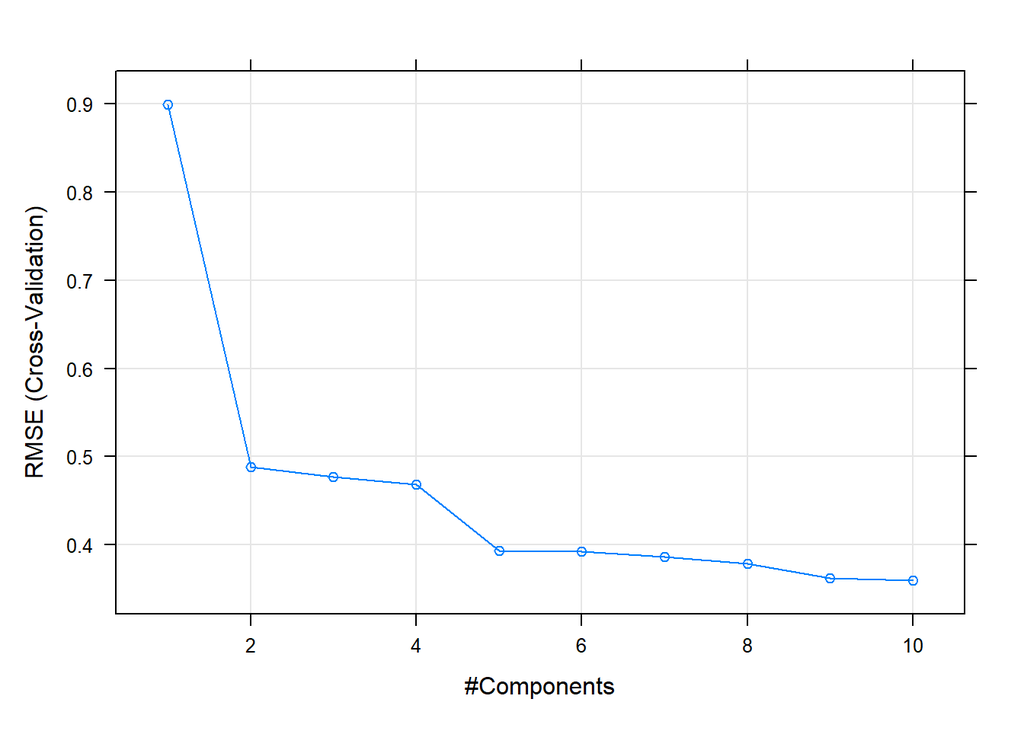

```r
plot(pcr_model)
```

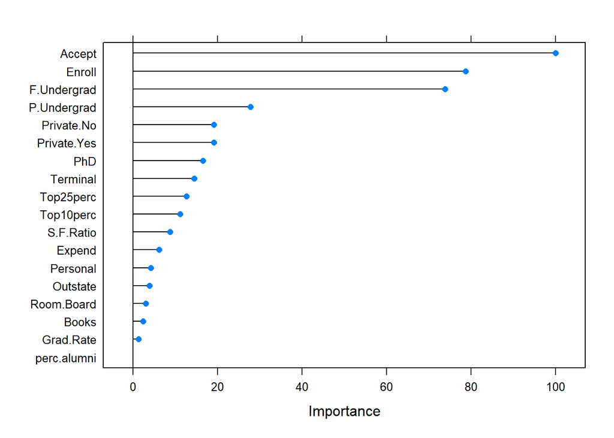

```r
plot(varImp(pcr_model))
```

6. **Fit a PLS model on the training set, with M chosen by cross-validation. Report the test error obtained, along with the value of M selected by cross-validation.**

```r
pls_model <- train(x = x_train, y = y_train,
                   method = 'pls',
                   trControl = trainControl(method = 'cv', number = 10),
                   tuneGrid = expand.grid(ncomp = 1:10))
(pls_info <- postResample(predict(pls_model, x_test), y_test))
```

```
##      RMSE  Rsquared       MAE
## 0.2792580 0.9209302 0.1572165
```

```r
coef(pls_model$finalModel)
```

```
## , , 10 comps
##
##                 .outcome
## Private.No   0.071314109
## Private.Yes -0.071314109
## Accept       1.039263053
## Enroll      -0.169855531
## Top10perc    0.235572152
## Top25perc   -0.070270182
## F.Undergrad -0.022580399
## P.Undergrad  0.032522451
## Outstate    -0.085919942
## Room.Board   0.036344367
## Books        0.004835496
## Personal     0.007546695
## PhD         -0.044709439
## Terminal     0.002332025
## S.F.Ratio    0.010868271
## perc.alumni -0.009046689
## Expend       0.072963738
## Grad.Rate    0.037425850
```

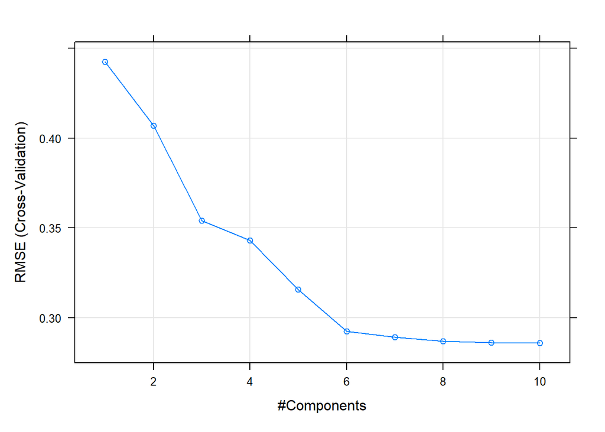

```r
plot(pls_model)
```

7. **Comment on the results obtained. How accurately can we predict the number of college applications received? Is there much difference among the test errors resulting from these five approaches?**

```r
as_data_frame(rbind(lin_info,
      ridge_info,
      lasso_info,
      pcr_info,
      pls_info)) %>%
    mutate(model = c('Linear', 'Ridge', 'Lasso', 'PCR', 'PLS')) %>%
    select(model, RMSE, Rsquared)
```

```
## # A tibble: 5 x 3
##   model   RMSE Rsquared
##   <chr>  <dbl>    <dbl>
## 1 Linear 0.280    0.920
## 2 Ridge  0.285    0.921
## 3 Lasso  0.291    0.914
## 4 PCR    0.323    0.892
## 5 PLS    0.279    0.921
```

```r
testing %>%
summarize(sd = sd(Apps))
```

```
##          sd
## 1 0.9818241
```

```r
require(ggthemes)
```

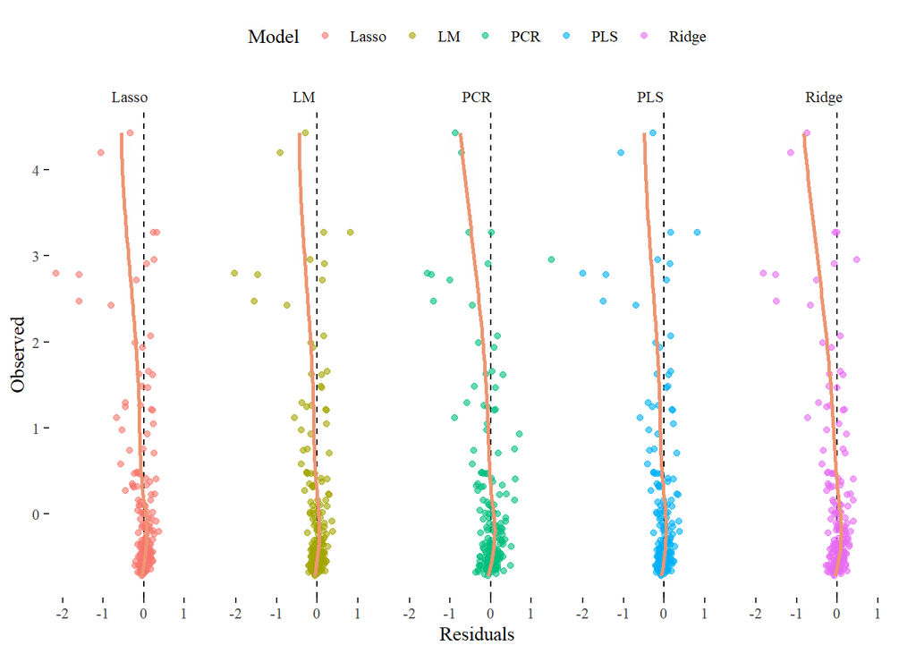

```r
residfunc <- function(fit, data) {
 predict(fit, data) - testing$Apps
}

data_frame(Observed = testing$Apps,
           LM = residfunc(lin_model, testing),
           Ridge = residfunc(ridge_fit, x_test),
           Lasso = residfunc(lasso_fit, x_test),
           PCR = residfunc(pcr_model, x_test),
           PLS = residfunc(pls_model, x_test)) %>%
    gather(Model, Residuals, -Observed) %>%
    ggplot(aes(Observed, Residuals, col = Model)) +
    geom_hline(yintercept = 0, lty = 2) +
    geom_point(alpha = 0.6) +
    geom_smooth(method = 'loess', alpha = 0.01, col = 'lightsalmon2') +
    facet_wrap(~ Model, ncol = 5) +
    theme_tufte() +
    theme(legend.position = 'top') +
    coord_flip()
```

All the models perform similarly with the exception of the PCR model. There is good accuracy found through this data.